# Reproducible Research Peer Assignment 1

Liu, Rong

Saturday, January 17, 2015

This document is an assignment from Reproducible Research. For more details on the requirements please see https://class.coursera.org/repdata-010/human_grading/view/courses/973511/assessments/3/submissions.

The data for this assignment can be downloaded from the course web site: https://d396qusza40orc.cloudfront.net/repdata%2Fdata%2Factivity.zip [52K]

The variables included in this dataset are: steps: Number of steps taking in a 5-minute interval (missing values are coded as NA) date: The date on which the measurement was taken in YYYY-MM-DD format interval: Identifier for the 5-minute interval in which measurement was taken

The dataset is stored in a comma-separated-value (CSV) file and there are a total of 17,568 observations in this dataset.

## Loading and preprocessing the data

```r
data = read.csv("./activity.csv")
#data[["date"]] = strptime(data[["date"]], "%Y-%m-%d")
summary(data)
```

```
##      steps                date          interval
##  Min.   :  0.00   2012-10-01:  288   Min.   :   0.0
##  1st Qu.:  0.00   2012-10-02:  288   1st Qu.: 588.8
##  Median :  0.00   2012-10-03:  288   Median :1177.5
##  Mean   : 37.38   2012-10-04:  288   Mean   :1177.5
##  3rd Qu.: 12.00   2012-10-05:  288   3rd Qu.:1766.2
##  Max.   :806.00   2012-10-06:  288   Max.   :2355.0
##  NA's   :2304     (Other)   :15840
```

## What is mean total number of steps taken per day?

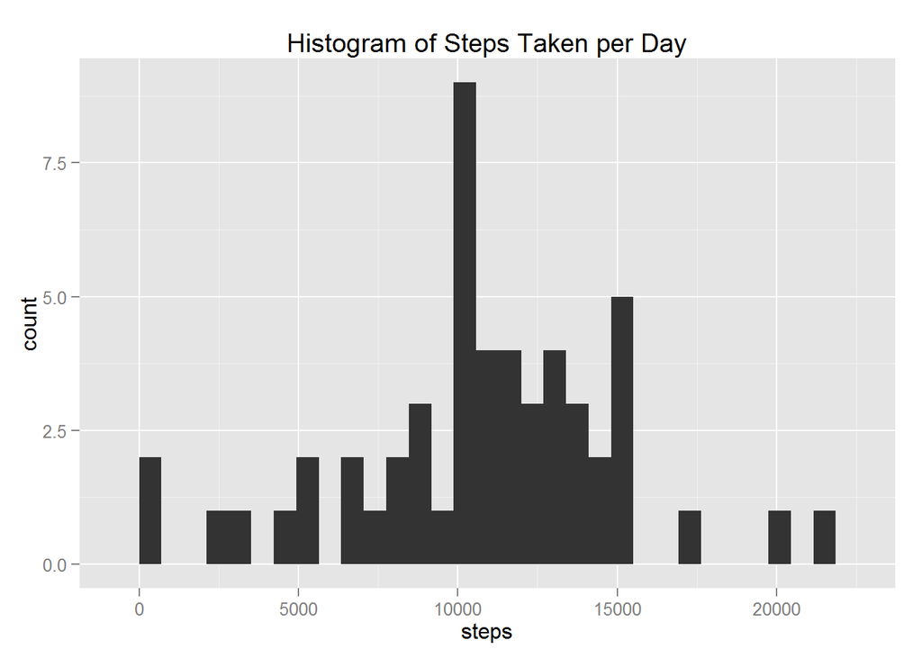

```r
library(dplyr)
library(ggplot2)
data_day = summarize(group_by(data, date), steps=sum(steps))
data_day = data_day[complete.cases(data_day), ]
ggplot(data_day, aes(x=steps)) + geom_histogram() + ggtitle("Histogram of Steps Taken per Day")
```

Mean steps taken per day:

```r
mean_val = mean(data_day$steps); mean_val
```

```
## [1] 10766.19
```

Median steps taken per day:

```r
median_val = median(data_day$steps); median_val
```

```
## [1] 10765
```

## What is the average daily activity pattern?

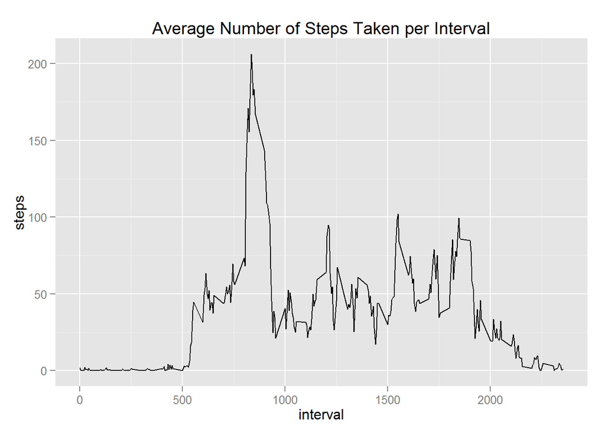

```r
data_interval = summarize(group_by(data, interval), steps=mean(steps, na.rm=TRUE))
data_interval = data_interval[complete.cases(data_interval), ]
ggplot(data_interval, aes(y=steps, x=interval)) + geom_line() + ggtitle("Average Number of Steps Taken per Interval")
```

```r
index = which.max(data_interval$steps)
data_interval$steps[index]
```

```
## [1] 206.1698
```

# Imputing missing values

The total number of missing values in the dataset is:

```r
nrow(data) - sum(complete.cases(data))
```

```
## [1] 2304
```

To fill the missing value in any 5-minute interval, We use the mean value for that 5-minute interval across all days. The data after filling missing values is:

```r
data_filled = data
for (i in 1:nrow(data)) {
    steps = data$steps[i]
    interval = data$interval[i]
    if (is.na(steps)) {
        data_filled[i, 1] = data_interval[data_interval$interval==interval, 2]
    }
}
summary(data_filled)
```

```
##      steps                date          interval
##  Min.   :  0.00   2012-10-01:  288   Min.   :   0.0
##  1st Qu.:  0.00   2012-10-02:  288   1st Qu.: 588.8
##  Median :  0.00   2012-10-03:  288   Median :1177.5
##  Mean   : 37.38   2012-10-04:  288   Mean   :1177.5
##  3rd Qu.: 27.00   2012-10-05:  288   3rd Qu.:1766.2
##  Max.   :806.00   2012-10-06:  288   Max.   :2355.0
##                   (Other)   :15840
```

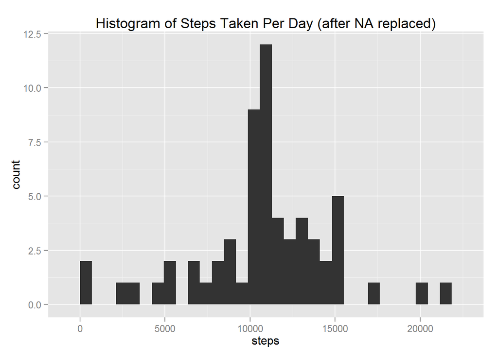

```r
data_filled_day = summarize(group_by(data_filled, date), steps=sum(steps))
ggplot(data_filled_day, aes(x=steps)) + geom_histogram() + ggtitle("Histogram of Steps Taken Per Day (after NA replaced)")
```

The mean of total number of steps taken per day is:

```r
mean_val_filled = mean(data_filled_day$steps); mean_val_filled
```

```
## [1] 10766.19
```

The median of total number of steps taken per day is:

```r
median_val_filled = median(data_filled_day$steps); median_val_filled
```

```
## [1] 10766.19
```

The mean value is as same as that of the orginal value. The difference between the median value and that of the original data is negligible.

## Are there differences in activity patterns between weekdays and weekends?

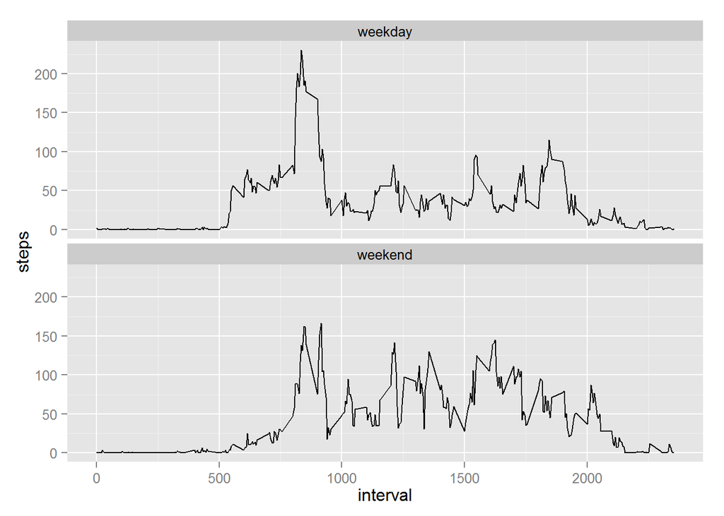

```r
data_weekday <-
    data_filled %>%
    mutate(day = ifelse(weekdays(as.POSIXct(date)) %in% c("Saturday", "Sunday"), "weekend", "weekday")) %>%
    group_by(interval, day) %>%
    summarize(steps=mean(steps))
ggplot(data_weekday, aes(interval,steps)) + geom_line() + facet_wrap(~day, nrow=2)
```